# Factors that Associate with Clients Subscribing to Term Deposit

Anthony Mallamaci

2025-10-10

# Question and Purpose

This analysis examines factors influencing a client’s subscription to a term deposit (y) for both association and predictive purposes. The goal is to identify which client and campaign features are associated with subscription probability and to build a predictive model for new clients.

## Model Building

The purpose of building the logistic regression model is to identify which client and campaign characteristics influence the likelihood of subscribing to a term deposit. By examining significant predictors, the model provides insights into the associations between features and the response variable and allows for reliable predictions for new clients. Ultimately, this analysis aims to guide targeted marketing strategies and improve campaign effectiveness.

```
##               GVIF Df GVIF^(1/(2*Df))
## age       2.240865  1        1.496952
## job       4.925955 11        1.075169
## marital   1.433076  2        1.094126
## education 2.413192  3        1.158151
## default   1.029426  1        1.014606
## balance   1.067101  1        1.033006
## housing   1.461225  1        1.208812
## loan      1.068289  1        1.033581
## contact   2.023148  2        1.192633
## day       1.372713  1        1.171628
## month     4.870271 11        1.074614
## duration  1.140464  1        1.067925
## campaign  1.152127  1        1.073372
## pdays     3.854828  1        1.963372
## previous  1.898583  1        1.377891
## poutcome  5.563404  3        1.331139
```

```
##            age balance   day duration campaign pdays previous     y
## age       1.00    0.08 -0.02     0.00    -0.01 -0.01     0.00  0.05
## balance   0.08    1.00 -0.01    -0.02    -0.01  0.01     0.03  0.02
## day      -0.02   -0.01  1.00    -0.02     0.16 -0.09    -0.06 -0.01
## duration  0.00   -0.02 -0.02     1.00    -0.07  0.01     0.02  0.40
## campaign -0.01   -0.01  0.16    -0.07     1.00 -0.09    -0.07 -0.06
## pdays    -0.01    0.01 -0.09     0.01    -0.09  1.00     0.58  0.10
## previous  0.00    0.03 -0.06     0.02    -0.07  0.58     1.00  0.12
## y         0.05    0.02 -0.01     0.40    -0.06  0.10     0.12  1.00
```

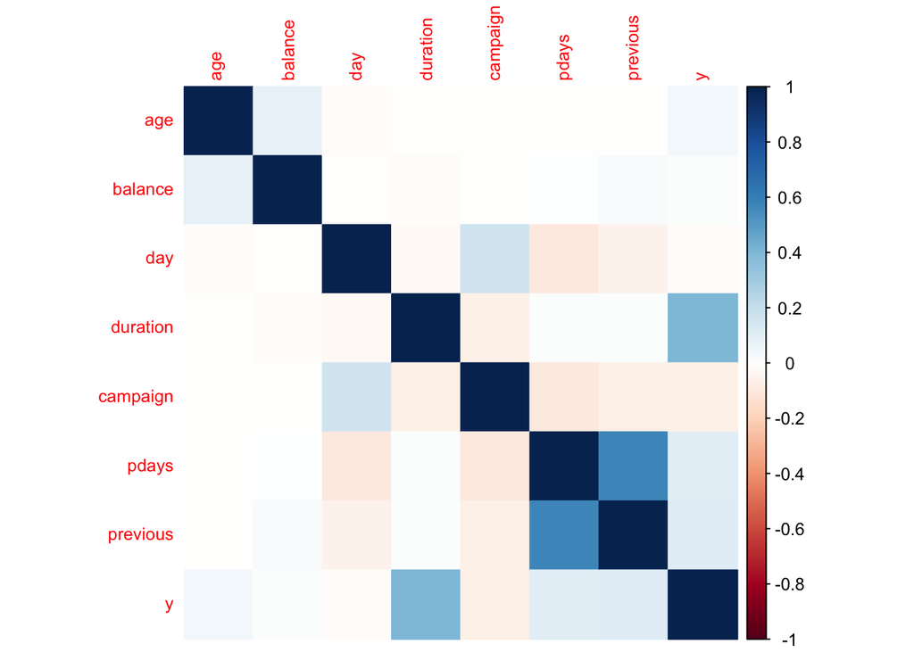

None of the numeric variables have a high correlation (>|0.8|) between each. This means we should not have an issue with multicollinearity.

## Reduced Model

The reduced model was created to simplify the initial logistic regression by retaining only the most influential predictors. Starting with a full model that included all demographic, financial, and campaign variables, backward stepwise selection based on AIC was applied to remove variables that contributed little to explaining subscription probability. This process resulted in a more parsimonious model that balances predictive accuracy with interpretability, highlighting the variables that have the strongest association with whether or not a client subscribes to the term deposit.

Summary table of significant tests

|  | Estimate | Std. Error | z value | Pr(>&#124;z&#124;) |
| --- | --- | --- | --- | --- |
| (Intercept) | -2.7318547 | 0.3608341 | -7.5709438 | 0.0000000 |
| maritalmarried | -0.5108288 | 0.1709685 | -2.9878530 | 0.0028094 |
| maritalsingle | -0.3181354 | 0.1864058 | -1.7066816 | 0.0878813 |
| educationsecondary | 0.1268075 | 0.1827658 | 0.6938248 | 0.4877921 |
| educationtertiary | 0.3810998 | 0.1913291 | 1.9918549 | 0.0463870 |
| educationunknown | -0.2831229 | 0.3395018 | -0.8339365 | 0.4043168 |
| housingyes | -0.3434167 | 0.1329758 | -2.5825498 | 0.0098073 |
| loanyes | -0.6430899 | 0.1981746 | -3.2450674 | 0.0011742 |
| contacttelephone | -0.0077099 | 0.2217915 | -0.0347617 | 0.9722698 |
| contactunknown | -1.4577768 | 0.2253170 | -6.4698925 | 0.0000000 |
| day | 0.0162954 | 0.0081149 | 2.0080895 | 0.0446338 |
| monthaug | -0.3180448 | 0.2457796 | -1.2940242 | 0.1956571 |
| monthdec | 0.2027593 | 0.6661682 | 0.3043665 | 0.7608487 |
| monthfeb | 0.1398131 | 0.2917392 | 0.4792400 | 0.6317679 |
| monthjan | -1.0851644 | 0.3768278 | -2.8797358 | 0.0039801 |
| monthjul | -0.7312482 | 0.2473493 | -2.9563387 | 0.0031132 |
| monthjun | 0.5600454 | 0.2975296 | 1.8823180 | 0.0597929 |
| monthmar | 1.6262687 | 0.3813054 | 4.2650025 | 0.0000200 |
| monthmay | -0.4734989 | 0.2311010 | -2.0488832 | 0.0404735 |
| monthnov | -0.8618761 | 0.2700920 | -3.1910465 | 0.0014176 |
| monthoct | 1.4102741 | 0.3255826 | 4.3315398 | 0.0000148 |
| monthsep | 0.7558952 | 0.4089156 | 1.8485359 | 0.0645249 |
| duration | 0.0041838 | 0.0001992 | 21.0055249 | 0.0000000 |
| campaign | -0.0722161 | 0.0281375 | -2.5665456 | 0.0102717 |
| poutcomeother | 0.4813847 | 0.2659176 | 1.8102781 | 0.0702527 |
| poutcomesuccess | 2.4145453 | 0.2681035 | 9.0060191 | 0.0000000 |
| poutcomeunknown | -0.0931105 | 0.1847998 | -0.5038451 | 0.6143702 |

## Predictive Model

The predictive model uses logistic regression to estimate whether a client will subscribe to a term deposit using demographic, financial, and campaign variables.

| marital | education | balance | housing | loan | contact | day | month | duration | campaign | poutcome | Predicted_Response |
| --- | --- | --- | --- | --- | --- | --- | --- | --- | --- | --- | --- |
| single | tertiary | 1200 | no | no | cellular | 15 | mar | 250 | 1 | success | 1 |
| married | secondary | 300 | yes | no | unknown | 23 | oct | 120 | 4 | failure | 0 |

The predictive model estimates whether a client will subscribe to a term deposit based on their characteristics. For the two hypothetical clients, it predicts that the single client with tertiary education and favorable campaign features will subscribe (1), while the married client with less favorable features will not (0).